# Universidade Federal da Paraíba Centro de Ciências Exatas e da Natureza Departamento de Estatística

**Apresentando o problema encontrado**

Professor

**Prof. Dr. Pedro Rafael D. Marinho**

Data da Avaliação

05/04/2024

**Nota**

Inicialmente, você deverá instalar os seguintes pacotes:

1. `remotes`: faça `install.packages("remotes")`;
2. `zmpg`: faça `remotes::install_github("prdm0/zmpg", force = TRUE)`;
3. `AcceptReject`: faça `remotes::install_github("prdm0/AcceptReject", force = TRUE)`;
4. `LambertW`: faça `install.packages("LambertW")`.

Essas são as dependências que são utilizadas nesse documento. O pacote `zmpg` é o pacote que implementa a distribuição do modelo de fragilidade ZMPG.

# Pacote e densidade da Katy

O pacote `zmpg` implementa a distribuição do modelo de fragilidade ZMPG para qualquer densidade base, seja ela uma densidade já implementada no R, como `dexp`, `dweibull`, `dgamma`, entre outras, como também densidades que que o usuário queira passar.

Apenas quero mostrar, nessa Seção, que os valores da densidade enviada por Katy batem com as do pacote. Para acessar a densidade enviada por Katy, basta clicar [aqui](https://docsend.dropbox.com/view/vbwh95ddaxrz57df).

No exemplo que segue, será utilizado a densidade de probabilidade de base a exponencial, que tem $h_0(x) = \lambda$ e $S_0(x) = e^{-\lambda x}$. Considere inicialmente os valores verdadeiros como sendo:

```r
# Parametros verdadeiros
mu = 10.7
phi = 4.5
rho = 3.2
lambda = 1.4
```

```r
# Densidade de Katy
pdf <- function(x, mu, phi, rho, lambda) {
  s0 <- exp(-lambda * x)
  delta <- (mu * phi)/(1 + mu * phi)

  kapa <- LambertW::W(-delta * s0 * exp(-delta))

  h0 <- lambda

  -rho * h0 * (exp(-1/phi * (kapa + delta))/phi) * kapa/(1 + kapa)
}

pdf(0.22, mu = mu, phi = phi, rho = rho, lambda = lambda)
```

```
[1] 0.597579
```

O valor obtido pela densidade de Katy, conforme o que foi escrito [aqui](https://docsend.dropbox.com/view/vbwh95ddaxrz57df) é 0.597579. O valor fornecido pelo pacote zmpg também irá fornecer o mesmo resultado. Veja:

```r
# Densidade do pacote zmpg
pdf_zmpg <- zmpg::pdf_fragility_zmpg(dexp)
pdf_zmpg(0.22, mu = mu, phi = phi, rho = rho, rate = lambda)
```

```
[1] 0.597579
attr(,"time")
[1] 0.22
attr(,"class")
[1] "pdf_fragility_zmpg"
```

Observe, portanto que o valor obtido pela densidade de Katy e pelo pacote `zmpg` são iguais. Note também como é fácil criar casos particulares usando a função `pdf_fragility_zmpg` do pacote zmpg.

# Pacote `AcceptReject`

Por meio do pacote [AcceptReject](https://prdm0.github.io/AcceptReject/), é possível utilizar o método da aceitação e rejeição de forma muito simples e rápida. O pacote permite gerar dados de qualquer função densidade de probabilidade (caso contínuo) ou função massa de probablidade (caso discreto).

Vamos por exemplo, gerar dados de uma distribuição Weibull com parâmetros $shape = 2.4$ e $scale = 2.7$. Para isso, basta fazer:

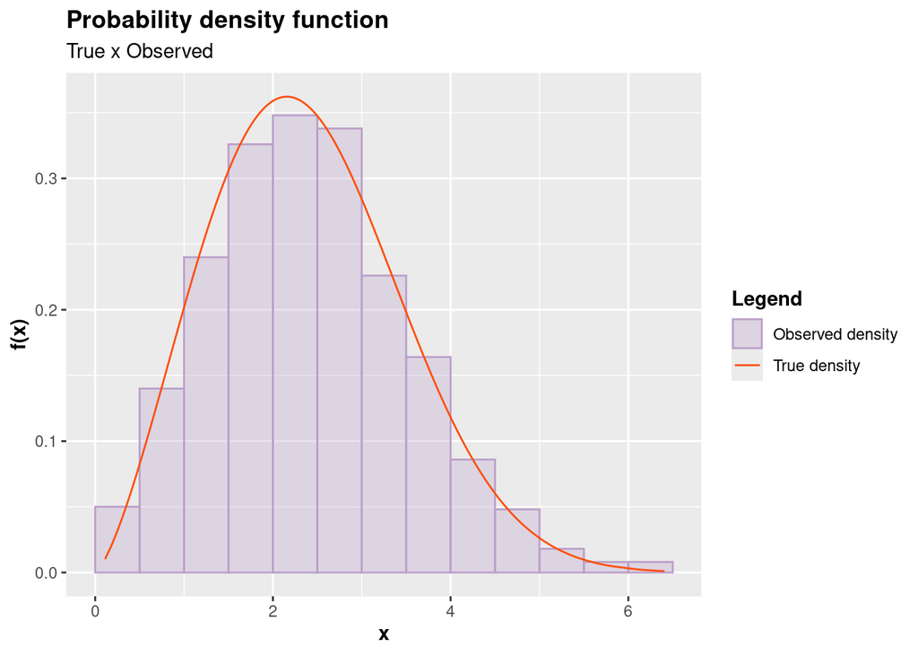

```r
library(AcceptReject)

# Garantindo reprodutibilidade
set.seed(0)

dados <-
  accept_reject(
    n = 1000, # Número de dados a serem gerados
    continuous = TRUE,
    f = dweibull,
    args_f = list(shape = 2.4, scale = 2.7), # Parâmetros da distribuição Weibull
    xlim = c(0, 10) # Suporte
  )

# Checando os dados gerados com a distribuição teórica
plot(dados)
```

Toda distribuição de probabilidade tem que ter, para ser útil, uma função de verossimilhança que não tenha problemas e que permita que possamos recuperar os parâmetros. Vamos fazer isso com a Weibull. Note que o R é uma linguagem vetorizada, e nunca precisamos escrever na íntegra a verossimilhança. Além disso, normalmente as funções de R, por *default*, minimizam. Pelo fato da função de verossimilhança ser convexa, o problema de minimização poderá ser convertido ao de maximização. Então maximizar $\ell(\cdot)$ é o mesmo que minimizar $-\ell(\cdot)$.

```r
# Função de verossimilhança
log_likelihood <- function(x, shape, scale){
  -sum(log(dweibull(x, shape = shape, scale = scale)))
}

# Minimizando a função de verossimilhança
estimativas <-
  optim(
    par = c(0.5, 0.5),
    fn = \(theta) log_likelihood(x = dados, shape = theta[1L], scale = theta[2L]),
    method = "L-BFGS-B",
    lower = 0,
    upper = 10
  )$par

# As estimativas de máxima verossimilhança foram
print(estimativas)
```

```
[1] 2.318791 2.728304
```

Assim, $\widehat{shape} =$ 2.3187913 e $\widehat{scale} =$ 2.728304, bem próximas ao valor verdadeira que são $shape = 2.4$ e $scale = 2.7$. Dessa forma, foi possível recuperar os parâmetros da distribuição Weibull.

# Modelo de fragilidade ZMPG

Na primeira Seção desse documento, já foi mostrado que a implementação do modelo de fragilidade ZMPG está correta de acordo com os documentos enviados e considerados para implementação do pacote. Vamos seguir a mesma análise que fizemos na Seção anterior para a distribuição Weibull, mas agora para a distribuição ZMPG. Consideraremos a ZMPG com a função densidade de probabilidade exponencial, como sendo a densidade base.

Vamos considerar inicialmente a verossimilhança perfilada, em que iremos setar os valores verdadeiros para $\mu$, $\phi$ e $\rho$ e iremos tentar recuperar (estimar) o parâmetro de base, isto é, vamos estimar o $\lambda$ pelo método de máxima verossimilhança.

```r
library(AcceptReject)

# Parâmetros verdadeiros
mu = 10.7
phi = 4.5
rho = 3.2
lambda = 1.4

# Garantindo reprodutibilidade
set.seed(0)

# Gerando dados da ZMPG-Exponencial
dados <-
  accept_reject(
    n = 1000, # Número de dados a serem gerados
    continuous = TRUE,
    f = pdf,
    args_f = list(mu = mu, phi = phi, rho = rho, lambda = lambda), # Parâmetros da ZMPG
    xlim = c(0, 5),
    parallel = TRUE # Paralelizando em sistemas Unix
  )

log_likelihood <- function(x, mu, phi, rho, lambda){
  -sum(log(pdf(x, mu = mu, phi = phi, rho = rho, lambda = lambda)))
}

estimativa <-
  optim(
    par = c(1),
    fn = \(theta) log_likelihood(x = dados, mu = mu, phi = phi, rho = rho, lambda = theta),
    method = "L-BFGS-B",
    lower = 0,
    upper = 5
  )$par
```

A estimativa do parâmetro $\lambda$ da distribuição base é $\widehat{\lambda} =$ 1.3501836. O valor verdadeiro é $\lambda = 1.4$. Portanto, a estimativa foi muito próxima do valor verdadeiro. Dessa forma, vemos que é possível recuperar o parâmetro de base.

Agora vamos considerar a perfilada um pouquinho diferente. Vamos fixar os valores de $\mu$, $\phi$ e $\lambda$ e vamos tentar recuperar o valor de $\rho$, sob o mesmo conjunto de dados. Continuaremos utilizando o método L-BFGS-B, para que possamos fixar o intervalo de busca e entender melhor o que está ocorrendo com as estimativas. Consideraremos três cenários: $\rho \in [0, 5]$, $\rho \in [0, 10]$ e $\rho \in [0, 100]$.

```r
cenario_1 <-
  optim(
    par = c(1),
    fn = \(theta) log_likelihood(x = dados, mu = mu, phi = phi, rho = theta, lambda = lambda),
    method = "L-BFGS-B",
    lower = 0,
    upper = 5
  )$par

cenario_2 <-
  optim(
    par = c(1),
    fn = \(theta) log_likelihood(x = dados, mu = mu, phi = phi, rho = theta, lambda = lambda),
    method = "L-BFGS-B",
    lower = 0,
    upper = 10
  )$par

cenario_3 <-
  optim(
    par = c(1),
    fn = \(theta) log_likelihood(x = dados, mu = mu, phi = phi, rho = theta, lambda = lambda),
    method = "L-BFGS-B",
    lower = 0,
    upper = 100
  )$par


# As estimativas de máxima verossimilhança foram
print(cenario_1)
```

```
[1] 5
```

```r
print(cenario_2)
```

```
[1] 10
```

```r
print(cenario_3)
```

```
[1] 100
```

Note que as estimativas foram $\widehat{\rho} =$ 5, $\widehat{\rho} =$ 10 e $\widehat{\rho} =$ 100. Dessa forma, percebe-se que as estimativas de máxima verossimilhança para o parâmetro $\rho$ converge para o limite superior de cada cenário, o que mostra, numericamente, que a função de verossimilhança é monótoca em $\rho$. Dessa forma, não é possível recuperar o valor verdadeiro pelo método de máxima verossimilhança.

# Onde investigar?

Minha sugestão é talvez investigar a construção do modelo de fragilidade. Adianto que o problema não está na função massa de probabilidade discreta ZMPG. Mostro isso abaixo, em que gero dados de uma variável aleatória discreta que segue a distribuição ZMPG e tento recuperar os parâmetros pelo método de máxima veorssimilhança.

```r
library(AcceptReject)
library(zmpg)
fp_zmpg <- function(x, mu, phi, rho){

  # Função indicadora
  ind <- function(y)
    ifelse(x == 0, 1, 0)

  (1 - rho) * ind(x) + rho * dgp(y = x, mu = mu, phi = phi)
}

fp_zmpg(0L:120L, 1.2, 1.5, 0.5) |> sum()
```

```
[1] 1
```

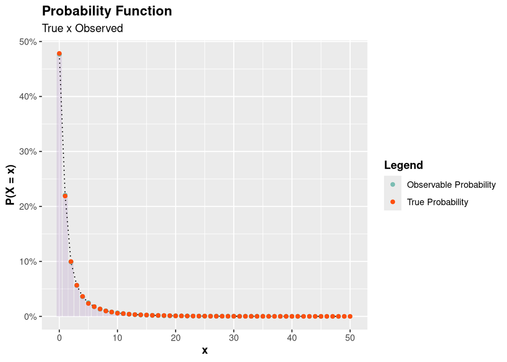

```r
# Garantindo reprodutibilidade
set.seed(0)

dados <-
  accept_reject(
    n = 100000,
    continuous = FALSE,
    f = fp_zmpg,
    args_f = list(mu = 1.2, phi = 1.5, rho = 1.5),
    xlim = c(0, 50),
    parallel = TRUE
  )

plot(dados)
```

```r
dados <- as.vector(dados)

log_likelihood <- function(x, mu, phi, rho){
  -sum(log(fp_zmpg(x, mu, phi, rho)))
}

estimativas <-
  optim(
    par = c(0.5, 0.5, 0.5),
    fn = function(par) log_likelihood(x = dados, mu = par[1], phi = par[2], rho = par[3]),
    method = "Nelder-Mead"
  )$par
```

Perceba que o método de máxima verossimilhança sobre o modelo discreto ZMPG foi capaz de recuperar os parâmetros verdadeiros, que são $\mu = 1.2$, $\phi = 1.5$ e $\rho = 1.5$. As estimativas foram $\widehat{\mu} =$ 1.2189938, $\widehat{\phi} =$ 1.4602695 e $\widehat{\rho} =$ 1.4693474. Portanto, o problema não está na função de massa de probabilidade discreta ZMPG, mas sim no modelo de fragilidade.

Será que não está no uso da fgp de Ambagaspitiya e Balakrishnan (1994), conduzindo à um modelo com verossimilhança com problema de monotonicidade? É preciso investigar alternativas. Note, por exemplo, que na fgp de Ambagaspitiya e Balakrishnan (1994), Eq. (3.4) da tese, $0 \leq t \leq 1$, e o modelo de fragilidade assume $t \geq 0$.

# Conclusão

Antes mesmo de pensar em uncluir covariáveis, há um problema importante que é o problema de monotonicidade da função de verossimilhança. Nesse exemplo usamos a distribuição ZMPG com a densidade base exponencial. Porém, faça o mesmo para outras, como Weibull e o problema continuar. Você será capaz de recuperar os parâmetros de base fixando os parâmetros da ZMPG-Weibull nos valores verdadeiros, mas não será capaz de recuperar os parâmetros que indexam o modelo de fragilidade ($\mu$, $\phi$ e $\rho$).

Portanto, seria importante tentar modificar o modelo de fragilidade e antes de prosseguir, tentar estudar numericamente a função de verossimilhança.

Não adianta incluir covariáveis se o modelo de fragilidade não está bem especificado e não se consegue recuperar, na situação mais simples (modelo sem covariáveis) os parâmetros verdadeiros.